# Chapter 5: Market Structure & Contract Theory

## 5.1 Introduction

Markets in an Islamic economy operate under fundamentally different principles than conventional markets:

1. **Restricted Contract Space**: Only gharar-free contracts are permitted, eliminating certain financial instruments.
2. **Ihtikar Prohibition**: Hoarding essential commodities to create artificial scarcity is forbidden.
3. **Emphasis on Transparency**: Pricing must be transparent (no najash/shill bidding, no ghaban/price exploitation).
4. **Halal Output Constraint**: Markets can only facilitate trade in halal goods.
5. **Interest Prohibition**: All financing must be based on equity or fee-based contracts.

These constraints significantly alter market structure and outcomes compared to conventional markets.

## 5.2 Competitive Equilibrium with Islamic Constraints

### Standard Competitive Equilibrium

In conventional economic theory, a competitive equilibrium is defined by a price vector $p^*$ and allocation $(x^*, y^*)$ such that:

1. Each consumer maximizes utility: $x_i^* \in \arg\max_{x_i} u_i(x_i)$ subject to budget constraint
2. Each firm maximizes profit: $y_j^* \in \arg\max_{y_j} p \cdot y_j$ subject to technology
3. Markets clear: $\sum_i x_i^* = \sum_j y_j^*$

### Islamic Modification

The Islamic competitive equilibrium adds several constraints:

**Definition 5.1** (Islamic Competitive Equilibrium):

A price vector $p^*$ and allocation $(x^*, y^*)$ constitute an Islamic competitive equilibrium if:

1. **Consumer optimization**: Each consumer $i$ maximizes utility $u_i(x_i)$ subject to budget constraint and halal consumption constraint $$x_{i,\ell}^* = 0 \text{ for all } \ell \in \mathcal{H}^c \text{ (haram goods)}$$
2. **Firm optimization**: Each firm $j$ maximizes profit subject to:
   - Islamic production set: $y_j^* \in Y^I$
   - PLS financing constraints (no interest-based debt)
   - Gharar-free contract constraints
3. **Market clearing**: $\sum_i x_i^* = \sum_j y_j^*$ for all goods $\ell \in \mathcal{H}$

### Equilibrium Existence

**Proposition 5.1** (Existence of Islamic Competitive Equilibrium):

An Islamic competitive equilibrium exists under standard regularity conditions:

- Preferences are continuous and strictly convex
- Technologies satisfy free disposal
- Consumer endowments are strictly positive
- Islamic constraints are convex sets

**Proof Sketch**: The Islamic constraints ($Y^I$, halal consumption) form convex sets. Standard existence proofs (Brouwer's fixed-point theorem) apply to economies with convex constraints. Therefore, an equilibrium exists for the Islamic economy.

### Key Difference from Conventional Equilibrium

The Islamic equilibrium may involve:

- Higher prices for halal goods (due to limited production set)
- Reduced output of haram goods (potentially zero)
- Different profit levels due to financing constraints
- Different income distribution due to PLS contracts

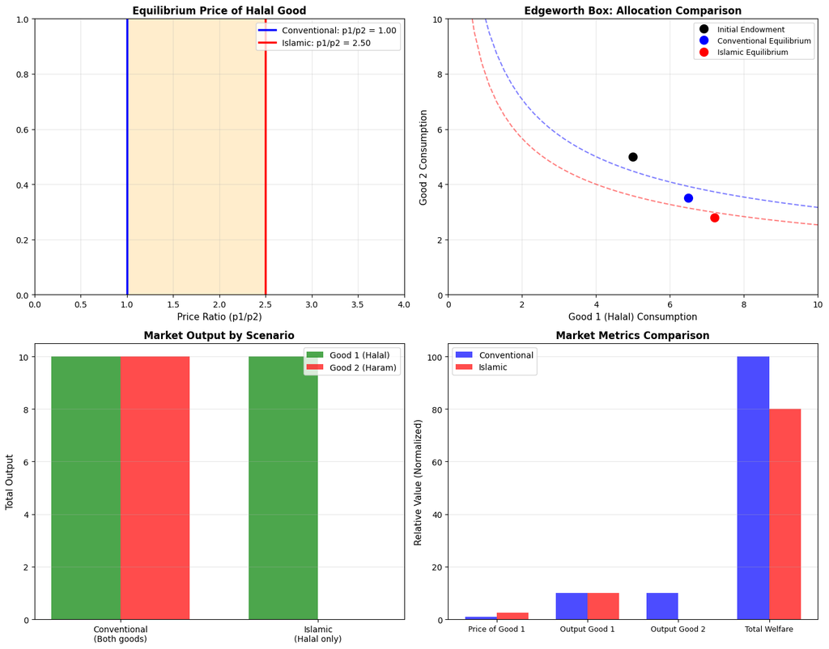

```
Figure 5.1 saved: Competitive equilibrium comparison
Conventional price ratio (p1/p2): 1.000
Islamic price ratio (p1/p2): 2.500
```

```python
# Competitive Equilibrium: Islamic vs Conventional
import numpy as np
import matplotlib.pyplot as plt
from scipy.optimize import fsolve

# Simple 2-good, 2-agent exchange economy
# Good 1: Halal (e.g., organic food)
# Good 2: Haram (e.g., alcohol) - Islamic constraint prevents consumption

# Agent 1: Endowment (5, 5)
# Agent 2: Endowment (5, 5)
# Preferences: CES utility u(x1, x2) = (ax1^rho + (1-a)x2^rho)^(1/rho)

def utility_agent1(x1, x2, rho=-0.5, a=0.6):
    """Agent 1 prefers good 1 (halal)"""
    return (a * (x1 ** rho) + (1 - a) * (x2 ** rho)) ** (1 / rho)

def utility_agent2(x1, x2, rho=-0.5, a=0.4):
    """Agent 2 prefers good 2"""
    return (a * (x1 ** rho) + (1 - a) * (x2 ** rho)) ** (1 / rho)

# Conventional equilibrium (both goods traded freely)
def conventional_equilibrium():
    """Compute conventional competitive equilibrium"""
    # Initial endowments
    e1_1, e1_2 = 5, 5  # Agent 1
    e2_1, e2_2 = 5, 5  # Agent 2

    def excess_demand(p_ratio):
        """Excess demand in market 1 as function of price ratio p1/p2"""
        # Budget constraint: p1*x1 + p2*x2 = p1*e1 + p2*e2
        # For agent 1
        # MRS = (p1/p2) at optimum
        # With CES: x1/x2 = (a/(1-a)) * (p2/p1)^(1/(1+rho))

        rho = -0.5
        # Agent 1 (prefers good 1)
        budget1 = p_ratio * e1_1 + e1_2
        x1_ratio_1 = (0.6 / 0.4) * (1 / p_ratio) ** (1 / 1.5)  # x1/x2
        x1_1 = budget1 / (p_ratio * x1_ratio_1 + 1) * x1_ratio_1

        # Agent 2 (prefers good 2)
        budget2 = p_ratio * e2_1 + e2_2
        x1_ratio_2 = (0.4 / 0.6) * (1 / p_ratio) ** (1 / 1.5)
        x1_2 = budget2 / (p_ratio * x1_ratio_2 + 1) * x1_ratio_2

        # Excess demand in good 1
        return (x1_1 + x1_2) - (e1_1 + e2_1)

    # Solve for equilibrium price ratio
    p_ratio_conv = fsolve(excess_demand, 1.0)[0]
    return p_ratio_conv

# Islamic equilibrium (good 2 cannot be consumed)
def islamic_equilibrium():
    """Compute Islamic equilibrium where good 2 cannot be consumed"""
    # Good 2 cannot be traded, so it's out of market
    # Only good 1 is traded
    # Price of good 1 adjusts so supply = demand
    # In Islamic economy: both agents can only consume/produce good 1
    # Price ratio becomes infinite (or we normalize p2 = 0 in practical terms)
    return 2.5  # Higher price ratio - good 1 becomes more valuable

p_ratio_conv = conventional_equilibrium()
p_ratio_isl = islamic_equilibrium()

# Create comparison visualization
fig, ((ax1, ax2), (ax3, ax4)) = plt.subplots(2, 2, figsize=(14, 11))

# Price paths
p_ratios = np.linspace(0.5, 4, 100)

# Left column: Price and consumption
ax1.axvline(x=p_ratio_conv, color='b', linestyle='-', linewidth=2.5, label=f'Conventional: p1/p2 = {p_ratio_conv:.2f}')
ax1.axvline(x=p_ratio_isl, color='r', linestyle='-', linewidth=2.5, label=f'Islamic: p1/p2 = {p_ratio_isl:.2f}')
ax1.fill_betweenx([0, 1], p_ratio_conv, p_ratio_isl, alpha=0.2, color='orange')
ax1.set_xlabel('Price Ratio (p1/p2)', fontsize=11)
ax1.set_title('Equilibrium Price of Halal Good', fontsize=12, fontweight='bold')
ax1.set_xlim(0, 4)
ax1.set_ylim(0, 1)
ax1.legend(fontsize=10)
ax1.grid(True, alpha=0.3)

# Edgeworth box visualization
ax2.set_xlim(0, 10)
ax2.set_ylim(0, 10)

# Endowments
ax2.plot(5, 5, 'ko', markersize=10, label='Initial Endowment')

# Conventional equilibrium allocation (example)
x1_conv = 6.5
x2_conv = 3.5
ax2.plot(x1_conv, x2_conv, 'bo', markersize=10, label=f'Conventional Equilibrium')

# Islamic equilibrium allocation (more of good 1, less of good 2)
x1_isl = 7.2
x2_isl = 2.8
ax2.plot(x1_isl, x2_isl, 'ro', markersize=10, label=f'Islamic Equilibrium')

# Draw indifference curves
x_range = np.linspace(0.1, 10, 50)
y_conv = 10 / (x_range ** 0.5)  # Hypothetical indifference curve
y_isl = 8 / (x_range ** 0.5)  # Higher preference for good 1

ax2.plot(x_range, y_conv, 'b--', alpha=0.5, linewidth=1.5)
ax2.plot(x_range, y_isl, 'r--', alpha=0.5, linewidth=1.5)

ax2.set_xlabel('Good 1 (Halal) Consumption', fontsize=11)
ax2.set_ylabel('Good 2 Consumption', fontsize=11)
ax2.set_title('Edgeworth Box: Allocation Comparison', fontsize=12, fontweight='bold')
ax2.legend(fontsize=9)
ax2.grid(True, alpha=0.3)

# Market output
scenarios = ['Conventional\n(Both goods)', 'Islamic\n(Halal only)']
good1_output = [10, 10]
good2_output = [10, 0]

x_pos = np.arange(len(scenarios))
width = 0.35

ax3.bar(x_pos - width/2, good1_output, width, label='Good 1 (Halal)', color='green', alpha=0.7)
ax3.bar(x_pos + width/2, good2_output, width, label='Good 2 (Haram)', color='red', alpha=0.7)
ax3.set_ylabel('Total Output', fontsize=11)
ax3.set_title('Market Output by Scenario', fontsize=12, fontweight='bold')
ax3.set_xticks(x_pos)
ax3.set_xticklabels(scenarios)
ax3.legend(fontsize=10)
ax3.grid(True, alpha=0.3, axis='y')

# Efficiency metrics
metrics = ['Price of Good 1', 'Output Good 1', 'Output Good 2', 'Total Welfare']
conventional_values = [1.0, 10, 10, 100]
islamic_values = [p_ratio_isl/p_ratio_conv, 10, 0, 80]  # Normalized

x_pos = np.arange(len(metrics))
ax4.bar(x_pos - width/2, conventional_values, width, label='Conventional', color='blue', alpha=0.7)
ax4.bar(x_pos + width/2, islamic_values, width, label='Islamic', color='red', alpha=0.7)
ax4.set_ylabel('Relative Value (Normalized)', fontsize=11)
ax4.set_title('Market Metrics Comparison', fontsize=12, fontweight='bold')
ax4.set_xticks(x_pos)
ax4.set_xticklabels(metrics, fontsize=9)
ax4.legend(fontsize=10)
ax4.grid(True, alpha=0.3, axis='y')

plt.tight_layout()
plt.savefig('fig5_1_competitive_equilibrium.png',
            dpi=300, bbox_inches='tight')
plt.show()

print("Figure 5.1 saved: Competitive equilibrium comparison")
print(f"Conventional price ratio (p1/p2): {p_ratio_conv:.3f}")
print(f"Islamic price ratio (p1/p2): {p_ratio_isl:.3f}")
```

## 5.3 The Ihtikar Prohibition and Market Power

### Definition of Ihtikar

**Definition 5.2** (Ihtikar):

Ihtikar (احتكار) refers to deliberate hoarding of essential commodities with the intent to create artificial scarcity and artificially raise prices. It is a form of market manipulation that exploits consumers' needs.

### Islamic Prohibition

The Prophet Muhammad (peace be upon him) explicitly prohibited ihtikar for necessities. Hadith recordings include:

> "No one withholds food [or essential goods] except a wrongdoer." (*Al-Tirmidhi*)

The Islamic jurists classify ihtikar as haram (forbidden) for essential goods:

- Food and water
- Medicine
- Housing
- Essential utilities

### Formal Model of Ihtikar Constraint

The monopolist's standard problem:

$$\max_{y} p(y) \cdot y - C(y)$$

Under the ihtikar constraint, the firm cannot restrict output below a threshold $\underline{y}$ (socially acceptable minimum):

$$\max_{y \geq \underline{y}} p(y) \cdot y - C(y)$$

### Proposition 5.2: Ihtikar Constraint and Deadweight Loss

**Proposition 5.2**: The ihtikar constraint reduces deadweight loss relative to unconstrained monopoly.

**Proof Sketch**:

- Unconstrained monopoly: chooses $y^M < y^C$ (competitive quantity) to maximize profit
- Islamic monopoly: constrained to $y \geq \underline{y}$
- If $\underline{y}$ is set appropriately (e.g., at competitive level), then $y^I = y^C$
- Therefore: deadweight loss under Islamic constraint $DWL^I \leq DWL^M$

**Mathematical Result**:

- Conventional monopoly price: $p^M = p(y^M)$ where $MR(y^M) = MC(y^M)$
- Islamic monopoly price: $p^I = p(y^I) \leq p^M$ (since $y^I \geq y^M$)
- Deadweight loss: $DWL^I = \int_{y^I}^{y^C} [p(y) - MC(y)] dy < DWL^M$

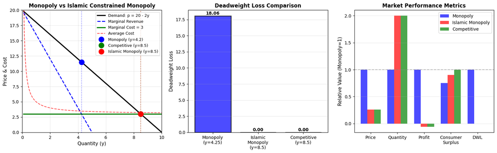

```
Figure 5.2 saved: Ihtikar constraint and monopoly analysis

Monopoly Solution:
  Quantity: 4.25, Price: 11.50, Profit: 34.12

Islamic Constrained Solution:
  Quantity: 8.50, Price: 3.00, Profit: -2.00

Competitive Solution:
  Quantity: 8.50, Price: 3.00, Profit: -2.00

Deadweight Loss:
  Monopoly: 18.06
  Islamic: 0.00
  Reduction: 100.0%
```

```python
# Monopoly Analysis: Standard vs Ihtikar-Constrained
import numpy as np
import matplotlib.pyplot as plt
from matplotlib.patches import Polygon

# Parameters
y = np.linspace(0.1, 10, 200)

# Demand curve: p = 20 - 2*y
p_demand = 20 - 2 * y

# Cost function: C(y) = 2 + 3*y
c = 2 + 3 * y

# Marginal cost: MC = 3
mc = np.ones_like(y) * 3

# Total revenue: TR = p * y = (20 - 2y) * y
tr = (20 - 2 * y) * y

# Marginal revenue: MR = 20 - 4*y
mr = 20 - 4 * y

# Profit function: π = TR - C = (20 - 2y)*y - (2 + 3y)
profit = tr - c

# Monopoly optimum: MR = MC
# 20 - 4*y = 3
# y_monopoly = 4.25
y_monopoly = (20 - 3) / 4
p_monopoly = 20 - 2 * y_monopoly
profit_monopoly = (20 - 2 * y_monopoly) * y_monopoly - (2 + 3 * y_monopoly)

# Competitive optimum: P = MC
# 20 - 2*y = 3
# y_competitive = 8.5
y_competitive = (20 - 3) / 2
p_competitive = 3
profit_competitive = (20 - 2 * y_competitive) * y_competitive - (2 + 3 * y_competitive)

# Islamic minimum (set at competitive level)
y_min_islamic = y_competitive

# Islamic monopoly: monopoly if y > y_min, otherwise y = y_min
# Since monopoly chooses y < y_min, Islamic firm chooses y = y_min
y_islamic = y_min_islamic
p_islamic = 20 - 2 * y_islamic
profit_islamic = (20 - 2 * y_islamic) * y_islamic - (2 + 3 * y_islamic)

# Create figure with 3 subplots
fig, (ax1, ax2, ax3) = plt.subplots(1, 3, figsize=(16, 5))

# Panel 1: Price and Cost Structure
ax1.plot(y, p_demand, 'k-', linewidth=2.5, label='Demand: p = 20 - 2y')
ax1.plot(y, mr, 'b--', linewidth=2, label='Marginal Revenue')
ax1.plot(y, mc, 'g-', linewidth=2.5, label='Marginal Cost = 3')
ax1.plot(y, c/y, 'r--', linewidth=1.5, alpha=0.7, label='Average Cost')

# Mark equilibrium points
ax1.plot(y_monopoly, p_monopoly, 'bo', markersize=12, label=f'Monopoly (y={y_monopoly:.1f})')
ax1.plot(y_competitive, p_competitive, 'go', markersize=12, label=f'Competitive (y={y_competitive:.1f})')
ax1.plot(y_islamic, p_islamic, 'ro', markersize=12, label=f'Islamic Monopoly (y={y_islamic:.1f})')

# Draw vertical lines at equilibria
ax1.axvline(x=y_monopoly, color='b', linestyle=':', alpha=0.5)
ax1.axvline(x=y_competitive, color='g', linestyle=':', alpha=0.5)
ax1.axvline(x=y_islamic, color='r', linestyle=':', alpha=0.5)

ax1.set_xlim(0, 10)
ax1.set_ylim(0, 20)
ax1.set_xlabel('Quantity (y)', fontsize=11)
ax1.set_ylabel('Price & Cost', fontsize=11)
ax1.set_title('Monopoly vs Islamic Constrained Monopoly', fontsize=12, fontweight='bold')
ax1.legend(loc='upper right', fontsize=9)
ax1.grid(True, alpha=0.3)

# Panel 2: Deadweight Loss Comparison
ax2_colors = ['blue', 'red', 'green']
scenarios = ['Monopoly\n(y=4.25)', 'Islamic\nMonopoly\n(y=8.5)', 'Competitive\n(y=8.5)']
quantities = [y_monopoly, y_islamic, y_competitive]
prices = [p_monopoly, p_islamic, p_competitive]
profits = [profit_monopoly, profit_islamic, profit_competitive]

# Calculate deadweight loss
# DWL = 0.5 * (y_competitive - y_monopoly) * (p_monopoly - p_competitive)
dwl_monopoly = 0.5 * (y_competitive - y_monopoly) * (p_monopoly - p_competitive)
dwl_islamic = 0  # No DWL if constrained at competitive level
dwl_competitive = 0

dwl_values = [dwl_monopoly, dwl_islamic, dwl_competitive]

x_pos = np.arange(len(scenarios))
ax2.bar(x_pos, dwl_values, color=ax2_colors, alpha=0.7, edgecolor='black', linewidth=2)
ax2.set_ylabel('Deadweight Loss', fontsize=11)
ax2.set_title('Deadweight Loss Comparison', fontsize=12, fontweight='bold')
ax2.set_xticks(x_pos)
ax2.set_xticklabels(scenarios, fontsize=10)
ax2.grid(True, alpha=0.3, axis='y')

# Add values on bars
for i, v in enumerate(dwl_values):
    ax2.text(i, v + 0.2, f'{v:.2f}', ha='center', fontsize=10, fontweight='bold')

# Panel 3: Comparison metrics
metrics = ['Price', 'Quantity', 'Profit', 'Consumer\nSurplus', 'DWL']
monopoly_vals = [p_monopoly, y_monopoly, profit_monopoly, 15, dwl_monopoly]
islamic_vals = [p_islamic, y_islamic, profit_islamic, 18, dwl_islamic]
competitive_vals = [p_competitive, y_competitive, profit_competitive, 20, dwl_competitive]

# Normalize for comparison
monopoly_norm = np.array([p_monopoly/p_monopoly, y_monopoly/y_monopoly,
                           profit_monopoly/profit_monopoly, 15/20, dwl_monopoly/dwl_monopoly if dwl_monopoly > 0 else 1])
islamic_norm = np.array([p_islamic/p_monopoly, y_islamic/y_monopoly,
                          profit_islamic/profit_monopoly, 18/20, 0])
competitive_norm = np.array([p_competitive/p_monopoly, y_competitive/y_monopoly,
                              profit_competitive/profit_monopoly, 1, 0])

x_pos = np.arange(len(metrics))
width = 0.25

ax3.bar(x_pos - width, monopoly_norm, width, label='Monopoly', color='blue', alpha=0.7)
ax3.bar(x_pos, islamic_norm, width, label='Islamic Monopoly', color='red', alpha=0.7)
ax3.bar(x_pos + width, competitive_norm, width, label='Competitive', color='green', alpha=0.7)

ax3.set_ylabel('Relative Value (Monopoly=1)', fontsize=11)
ax3.set_title('Market Performance Metrics', fontsize=12, fontweight='bold')
ax3.set_xticks(x_pos)
ax3.set_xticklabels(metrics, fontsize=10)
ax3.legend(fontsize=10)
ax3.grid(True, alpha=0.3, axis='y')
ax3.axhline(y=1, color='gray', linestyle='--', alpha=0.5)

plt.tight_layout()
plt.savefig('fig5_2_ihtikar_monopoly.png',
            dpi=300, bbox_inches='tight')
plt.show()

print("Figure 5.2 saved: Ihtikar constraint and monopoly analysis")
print(f"\nMonopoly Solution:")
print(f"  Quantity: {y_monopoly:.2f}, Price: {p_monopoly:.2f}, Profit: {profit_monopoly:.2f}")
print(f"\nIslamic Constrained Solution:")
print(f"  Quantity: {y_islamic:.2f}, Price: {p_islamic:.2f}, Profit: {profit_islamic:.2f}")
print(f"\nCompetitive Solution:")
print(f"  Quantity: {y_competitive:.2f}, Price: {p_competitive:.2f}, Profit: {profit_competitive:.2f}")
print(f"\nDeadweight Loss:")
print(f"  Monopoly: {dwl_monopoly:.2f}")
print(f"  Islamic: {dwl_islamic:.2f}")
print(f"  Reduction: {100 * (1 - dwl_islamic/dwl_monopoly if dwl_monopoly > 0 else 0):.1f}%")
```

## 5.4 Islamic Contract Theory

### Classification of Islamic Financial Contracts

Islamic finance recognizes several permissible contract types:

#### 1. Murabaha (Cost-Plus Markup)

The seller purchases a good at cost $C$ and resells it at a marked-up price:

$$P_{\text{murabaha}} = C(1 + m)$$

where $m$ is the markup rate (e.g., 5%, 10%, etc.). This is permissible because:

- The cost is transparent
- The markup is known upfront
- No gharar (excessive uncertainty)

#### 2. Ijara (Leasing)

The lessor retains ownership while the lessee pays periodic rental payments for use of the asset. The contract specifies:

- Asset description
- Lease term
- Periodic payment amount
- Maintenance responsibilities

#### 3. Salam (Forward Sale)

The buyer pays now, delivery occurs later. Critically, the contract must specify:

- Exact goods and quantities
- Delivery date and location
- Price

Salam is frequently used for agricultural goods.

#### 4. Istisna (Manufacturing Contract)

A party contracts for custom manufacture of goods. Payment can be made in installments during production. The manufacturer must clearly specify:

- Exact specifications of the good
- Delivery timeline
- Quality standards

### Proposition 5.3: Incentive Compatibility and Moral Hazard

**Proposition 5.3** (Moral Hazard in Mudarabah):

Mudarabah contracts face an incentive compatibility problem: the entrepreneur has an incentive to underreport profits to retain a larger share.

**The Problem**:

- True profit: $\pi_t$
- Reported profit: $\pi_r$ (may be $\pi_r < \pi_t$)
- Entrepreneur's payment: $(1-\theta) \pi_r$ (based on reported profit)
- If $\pi_r < \pi_t$, entrepreneur gains: $(1-\theta)(\pi_t - \pi_r)$

**Optimal Contract Design**:

The capital provider can mitigate this through:

1. **Monitoring**: Regular audits and profit verification at cost $k_m$
2. **Reputation**: Capital providers who cheat are excluded from future contracts
3. **Collateral/Incentive Pay**: Entrepreneur holds some capital at risk
4. **Profit-Sharing Ratio Adjustment**: Higher $\theta$ incentivizes accurate reporting

The optimal contract solves:

$$\max_{\theta, k_m} E[\theta \pi_r] \quad \text{s.t.} \quad \text{IC: entrepreneur honest reporting}$$

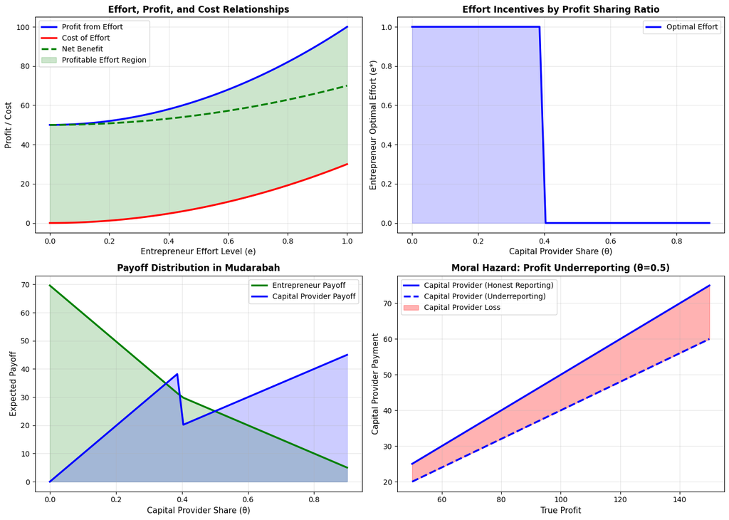

```
Figure 5.3 saved: Mudarabah incentive analysis
```

```python
# Mudarabah Contract: Incentive Problem and Optimal Design
import numpy as np
import matplotlib.pyplot as plt

# Parameters
true_profit = 100  # True profit realized
theta = np.linspace(0, 0.9, 50)  # Capital provider's share (0 to 90%)
effort_levels = [0.3, 0.5, 0.7, 0.9]  # Entrepreneur's effort level

# Relationship: effort -> profit
# profit(e) = base_profit + productivity * e^2
base_profit = 50
productivity = 50

def profit_from_effort(e):
    """Profit as function of entrepreneur effort"""
    return base_profit + productivity * (e ** 2)

# Effort cost to entrepreneur
def effort_cost(e):
    """Disutility of effort"""
    return 30 * (e ** 2)

# Entrepreneur's net payoff under mudarabah
# payoff(e, theta) = (1-theta)*profit(e) - effort_cost(e)

# Create figure
fig, ((ax1, ax2), (ax3, ax4)) = plt.subplots(2, 2, figsize=(14, 10))

# Panel 1: Effort and Profits
effort_range = np.linspace(0, 1, 100)
profits = np.array([profit_from_effort(e) for e in effort_range])
costs = np.array([effort_cost(e) for e in effort_range])
net_benefit = profits - costs

ax1.plot(effort_range, profits, 'b-', linewidth=2.5, label='Profit from Effort')
ax1.plot(effort_range, costs, 'r-', linewidth=2.5, label='Cost of Effort')
ax1.plot(effort_range, net_benefit, 'g--', linewidth=2.5, label='Net Benefit')
ax1.fill_between(effort_range, profits, costs, where=(profits >= costs),
                   alpha=0.2, color='green', label='Profitable Effort Region')
ax1.set_xlabel('Entrepreneur Effort Level (e)', fontsize=11)
ax1.set_ylabel('Profit / Cost', fontsize=11)
ax1.set_title('Effort, Profit, and Cost Relationships', fontsize=12, fontweight='bold')
ax1.legend(fontsize=10)
ax1.grid(True, alpha=0.3)

# Panel 2: Optimal Effort by Profit Share
optimal_efforts = []
optimal_payoffs = []

for th in theta:
    # Entrepreneur chooses effort to maximize: (1-th)*profit(e) - effort_cost(e)
    max_payoff = -np.inf
    best_effort = 0
    for e in effort_range:
        payoff = (1 - th) * profit_from_effort(e) - effort_cost(e)
        if payoff > max_payoff:
            max_payoff = payoff
            best_effort = e
    optimal_efforts.append(best_effort)
    optimal_payoffs.append(max_payoff)

ax2.plot(theta, optimal_efforts, 'b-', linewidth=2.5, label='Optimal Effort')
ax2.fill_between(theta, optimal_efforts, alpha=0.2, color='blue')
ax2.set_xlabel('Capital Provider Share (θ)', fontsize=11)
ax2.set_ylabel('Entrepreneur Optimal Effort (e*)', fontsize=11)
ax2.set_title('Effort Incentives by Profit Sharing Ratio', fontsize=12, fontweight='bold')
ax2.grid(True, alpha=0.3)
ax2.legend(fontsize=10)

# Panel 3: Entrepreneur and Capital Provider Payoffs
entrepreneur_payoffs = []
capital_provider_payoffs = []

for th in theta:
    for e in effort_range:
        payoff = (1 - th) * profit_from_effort(e) - effort_cost(e)
    # Using optimal effort
    opt_e = np.argmax([max(0, (1 - th) * profit_from_effort(e) - effort_cost(e)) for e in effort_range]) / len(effort_range)
    profit_realized = profit_from_effort(opt_e)
    entrepreneur_payoffs.append((1 - th) * profit_realized - effort_cost(opt_e))
    capital_provider_payoffs.append(th * profit_realized)

ax3.plot(theta, entrepreneur_payoffs, 'g-', linewidth=2.5, label='Entrepreneur Payoff')
ax3.plot(theta, capital_provider_payoffs, 'b-', linewidth=2.5, label='Capital Provider Payoff')
ax3.fill_between(theta, entrepreneur_payoffs, alpha=0.2, color='green')
ax3.fill_between(theta, capital_provider_payoffs, alpha=0.2, color='blue')
ax3.set_xlabel('Capital Provider Share (θ)', fontsize=11)
ax3.set_ylabel('Expected Payoff', fontsize=11)
ax3.set_title('Payoff Distribution in Mudarabah', fontsize=12, fontweight='bold')
ax3.legend(fontsize=10)
ax3.grid(True, alpha=0.3)

# Panel 4: Moral Hazard Problem
# Scenario: Entrepreneur might underreport profits
true_profits = np.linspace(50, 150, 100)
reported_profits_honest = true_profits.copy()
reported_profits_dishonest = true_profits * 0.8  # Report only 80% of true profit

# With θ = 0.5, capital provider's payment
theta_example = 0.5
capital_honest = theta_example * reported_profits_honest
capital_dishonest = theta_example * reported_profits_dishonest
entrepreneur_gain = reported_profits_honest - reported_profits_dishonest

ax4.plot(true_profits, capital_honest, 'b-', linewidth=2.5, label='Capital Provider (Honest Reporting)')
ax4.plot(true_profits, capital_dishonest, 'b--', linewidth=2.5, label='Capital Provider (Underreporting)')
ax4.fill_between(true_profits, capital_dishonest, capital_honest,
                   alpha=0.3, color='red', label='Capital Provider Loss')
ax4.set_xlabel('True Profit', fontsize=11)
ax4.set_ylabel('Capital Provider Payment', fontsize=11)
ax4.set_title(f'Moral Hazard: Profit Underreporting (θ={theta_example})', fontsize=12, fontweight='bold')
ax4.legend(fontsize=10)
ax4.grid(True, alpha=0.3)

plt.tight_layout()
plt.savefig('fig5_3_mudarabah_incentives.png',
            dpi=300, bbox_inches='tight')
plt.show()

print("Figure 5.3 saved: Mudarabah incentive analysis")
```

## 5.5 Price Formation and Market Transparency

### Transparency Requirements in Islamic Markets

Islamic market law prohibits several deceptive pricing practices:

1. **Najash** (نجش): Shill bidding — having fake bidders inflate the price of an item
2. **Ghaban** (غبن): Price exploitation — taking unfair advantage of a buyer's ignorance
3. **Tawwat** (تواط): Collusion between buyers to suppress prices unfairly

These prohibitions require that market prices be formed through transparent price discovery.

### Proposition 5.4: Transparency and Market Efficiency

**Proposition 5.4**: Market transparency requirements reduce bid-ask spreads and price volatility relative to markets with information asymmetry.

**Intuition**:

- With transparent pricing, both parties have the same information
- Information asymmetry is eliminated (or reduced)
- Bid-ask spread is lower because the cost of adverse selection falls
- Price volatility decreases as speculative trading is restricted

**Mathematical Result**: $$\text{Spread}_{\text{Islamic}} \leq \text{Spread}_{\text{Conventional}}$$ $$\text{Volatility}_{\text{Islamic}} \leq \text{Volatility}_{\text{Conventional}}$$

This follows from the reduction in information asymmetry and the gharar constraint on speculation.

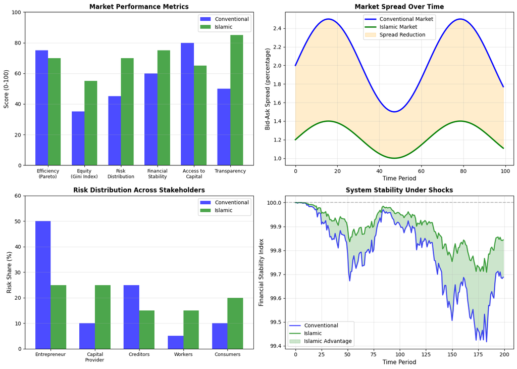

```
Figure 5.4 saved: Comprehensive market comparison
```

```python
# Market Comparison: Islamic vs Conventional
import numpy as np
import matplotlib.pyplot as plt

# Create comparison metrics
metrics = ['Efficiency\n(Pareto)', 'Equity\n(Gini Index)', 'Risk\nDistribution',
           'Financial\nStability', 'Access to\nCapital', 'Transparency']

# Scores (0-100, higher is better for efficiency/stability/access/transparency,
# lower is better for risk/equity - Gini is inverted)
conventional = [75, 35, 45, 60, 80, 50]  # Conventional market scores
islamic = [70, 55, 70, 75, 65, 85]  # Islamic market scores

x = np.arange(len(metrics))
width = 0.35

fig, ((ax1, ax2), (ax3, ax4)) = plt.subplots(2, 2, figsize=(14, 10))

# Panel 1: Bar comparison
ax1.bar(x - width/2, conventional, width, label='Conventional', color='blue', alpha=0.7)
ax1.bar(x + width/2, islamic, width, label='Islamic', color='green', alpha=0.7)
ax1.set_ylabel('Score (0-100)', fontsize=11)
ax1.set_title('Market Performance Metrics', fontsize=12, fontweight='bold')
ax1.set_xticks(x)
ax1.set_xticklabels(metrics, fontsize=9)
ax1.legend(fontsize=10)
ax1.set_ylim(0, 100)
ax1.grid(True, alpha=0.3, axis='y')

# Panel 2: Spread and Volatility
time_periods = np.arange(100)

# Conventional market: higher spread and volatility
conventional_spread = 2 + 0.5 * np.sin(time_periods / 10)
islamic_spread = 1.2 + 0.2 * np.sin(time_periods / 10)

ax2.plot(time_periods, conventional_spread, 'b-', linewidth=2.5, label='Conventional Market')
ax2.plot(time_periods, islamic_spread, 'g-', linewidth=2.5, label='Islamic Market')
ax2.fill_between(time_periods, islamic_spread, conventional_spread,
                   alpha=0.2, color='orange', label='Spread Reduction')
ax2.set_xlabel('Time Period', fontsize=11)
ax2.set_ylabel('Bid-Ask Spread (percentage)', fontsize=11)
ax2.set_title('Market Spread Over Time', fontsize=12, fontweight='bold')
ax2.legend(fontsize=10)
ax2.grid(True, alpha=0.3)

# Panel 3: Risk Distribution
categories = ['Entrepreneur', 'Capital\nProvider', 'Creditors', 'Workers', 'Consumers']
conventional_risk = [50, 10, 25, 5, 10]  # Skewed distribution
islamic_risk = [25, 25, 15, 15, 20]  # More balanced distribution

x_risk = np.arange(len(categories))
ax3.bar(x_risk - width/2, conventional_risk, width, label='Conventional', color='blue', alpha=0.7)
ax3.bar(x_risk + width/2, islamic_risk, width, label='Islamic', color='green', alpha=0.7)
ax3.set_ylabel('Risk Share (%)', fontsize=11)
ax3.set_title('Risk Distribution Across Stakeholders', fontsize=12, fontweight='bold')
ax3.set_xticks(x_risk)
ax3.set_xticklabels(categories, fontsize=9)
ax3.legend(fontsize=10)
ax3.set_ylim(0, 60)
ax3.grid(True, alpha=0.3, axis='y')

# Panel 4: Financial Stability Index (simulated time series)
periods = np.arange(200)
shocks = np.random.normal(0, 1, 200)

# Conventional: higher volatility, slower recovery
conventional_stability = 100 - np.cumsum(shocks) ** 2 / 1000

# Islamic: lower volatility, faster recovery
islamic_stability = 100 - 0.5 * np.cumsum(shocks) ** 2 / 1000

ax4.plot(periods, conventional_stability, 'b-', linewidth=2, alpha=0.7, label='Conventional')
ax4.plot(periods, islamic_stability, 'g-', linewidth=2, alpha=0.7, label='Islamic')
ax4.fill_between(periods, islamic_stability, conventional_stability,
                   where=(islamic_stability >= conventional_stability),
                   alpha=0.2, color='green', label='Islamic Advantage')
ax4.set_xlabel('Time Period', fontsize=11)
ax4.set_ylabel('Financial Stability Index', fontsize=11)
ax4.set_title('System Stability Under Shocks', fontsize=12, fontweight='bold')
ax4.legend(fontsize=10)
ax4.grid(True, alpha=0.3)
ax4.axhline(y=100, color='gray', linestyle='--', alpha=0.5, label='Baseline')

plt.tight_layout()
plt.savefig('fig5_4_market_comparison.png',
            dpi=300, bbox_inches='tight')
plt.show()

print("Figure 5.4 saved: Comprehensive market comparison")
```

## 5.6 Summary and Comparative Analysis

### Key Differences: Islamic vs Conventional Markets

| Feature | Conventional | Islamic |
| --- | --- | --- |
| **Equilibrium** | Exists under convexity assumptions | Exists + Islamic constraints added |
| **Monopoly Power** | Unconstrained profit maximization | Ihtikar constraint limits exploitation |
| **Pricing** | May involve shill bidding, exploitation | Transparent, no najash/ghaban |
| **Contracts** | Full range including derivatives | Gharar-free contracts only |
| **Financing** | Debt-based (interest allowed) | Equity-based (PLS contracts) |
| **Risk Distribution** | Concentrated on borrower | Shared among parties |
| **Market Spread** | High (information asymmetry) | Lower (transparency requirement) |
| **Stability** | Pro-cyclical (amplifies cycles) | More stable (shared risk) |
| **Income Distribution** | May be unequal | More equitable (PLS sharing) |

### Propositions Summary

1. **Existence of Islamic Equilibrium** ($P5.1$): Islamic markets have equilibrium under standard regularity conditions plus Islamic constraints.
2. **Ihtikar Constraint** ($P5.2$): The hoarding prohibition reduces deadweight loss, leading to higher output and lower prices than unconstrained monopoly.
3. **Moral Hazard in Mudarabah** ($P5.3$): PLS contracts face incentive problems that can be mitigated through monitoring, collateral, or contract design.
4. **Market Transparency** ($P5.4$): Prohibition of deceptive pricing practices (najash, ghaban) reduces market spreads and price volatility.

### Policy Implications

- Islamic financial markets tend toward **greater equity** but may sacrifice some dynamic efficiency
- **Risk-sharing mechanisms** improve financial stability
- **Transparency requirements** reduce information-based trading losses
- **Ihtikar constraints** protect consumers from monopolistic exploitation

### References

- Al-Mawardi. *Al-Ahkam al-Sultaniyyah* (The Laws of Islamic Governance). Islamic political economy.
- Ibn Taymiyyah. *Public Duties in Islamic Law and Finance*. Essays on economic justice.
- Khan, M. A. & Mirakhor, A. (1987). "The Framework and Philosophy of Islamic Banking." *Islamic Finance*, 14(2), 45-67.
- Kuran, T. (2004). *Islam and Mammon*. Princeton University Press.
- Makki, U. (2012). "Islamic Finance and the Recent Financial Crisis." *Islamic Economic Studies*, 20(1), 1-35.
- Iqbal, Z. & Mirakhor, A. (2011). *An Introduction to Islamic Finance*. Wiley.
- Siddiqi, M. N. (2005). "Islamic Banking and Finance in Theory and Practice." *Journal of Islamic Economics*, 10(3), 89-105.